# AM10 Individual Assignment

Mingqi Yin

2022-11-08

*Please note that my graphs don’t display properly in this html, hence I have included the png files in the assignment too. Sorry for the inconvinience.*

# 1 Question 1: Grading JP Morgan Visualisation

Text:

- 6-12 descriptive title: 2
- Subtitle providing additional information: 2
- Text size readable: 2
- Text horizontal: 2
- Data labelled directly: 1 (not labelled directly)
- Labels used sparingly: 1 (crammed)

Arrangement:

- Accurate proportions: 2
- Intentionally ordered: 0 (no visible ordering)
- Axis intervals are equidistant: 2
- Graph is 2D: 2
- Display is free from decoration: 2

Colour:

- Colour scheme is intentional: 0 (no visible intentions in colour scheme)
- Colour used to highlight key patterns: 0 (no highlighting of key patterns)
- Colour is legible when printed in black and white: 0 (not legible)
- Colour is legible for people with colour-blindness: 0 (not legible)
- Text sufficiently contrasts background: 2

Lines:

- Gridlines are muted: 2
- Graph does not have border line: 2
- Axes do not have unnecessary tick marks or axis lines: 2
- Graph has one horizontal and one vertical axis: 2

Overall:

- Graph highlights significant finding or conclusion: 2
- Type of graph is appropriate for data: 2
- Graph has appropriate level of precision: 1 (may be too precise)
- Individual chart elements work together to reinforce the overarching takeaway: 1 (too many lines to illustrate the same idea)

Total:

- 34/48 = 70.83%

# 2 Question 2 - Ugly Graph

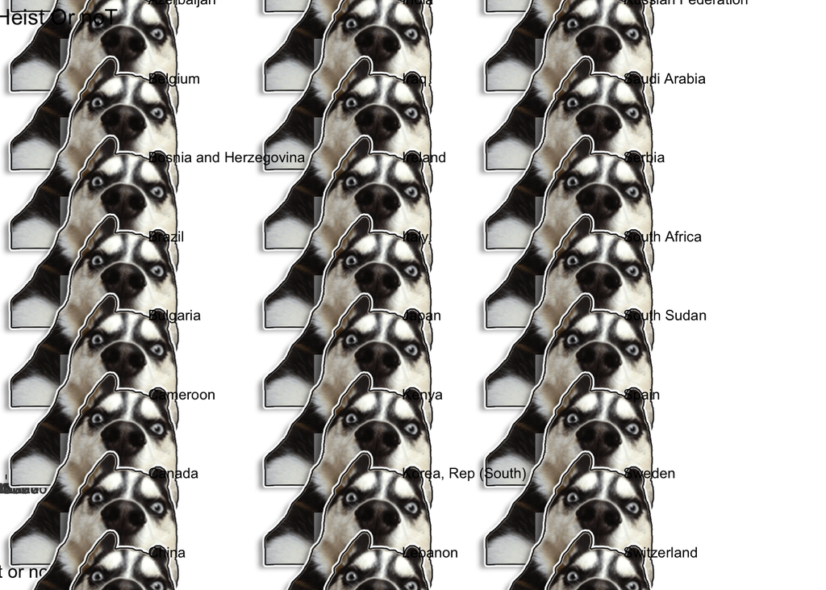

```r
# read data
atheism <- read_csv("atheism copy.csv")

# create binary variable for whether atheism
atheism <- atheism %>%
  mutate(binary = ifelse(test = response == "non-atheist",
                         yes = 0,
                         no = 1))

# produce summary table
sum_atheism <- atheism %>%
  group_by(nationality, year, binary) %>%
  summarise(count = n())

# plot diagram
ggplot(data = sum_atheism,
       aes(x = binary, y = count, colour = nationality)) + # binary not being a factor variable
  geom_dog(dog = "husky_2", size = 17) +
  facet_wrap(~nationality) + # making it messy
  labs(title = "aTHeist Or noT", # doesn't make sense
       x = "atheist or not",
       y = "number") +
  theme_dark() # make it messy
```

# 3 Question 3 - Stop and Search

```r
# read and clean
stop_and_search <- read_csv("stop_and_search.csv") %>%
  janitor::clean_names()

stop_and_search <- stop_and_search %>%
  mutate(date = as.character(date))

# unique(dataframe$variable) unique values in variables to check
stop_and_search_clean <- stop_and_search %>%
  select(-policing_operation, -self_defined_ethnicity, -outcome_linked_to_object_of_search, -removal_of_more_than_just_outer_clothing, -date, -legislation, -part_of_a_policing_operation, -latitude, -longitude)

# variables of interest
# type: person, vehicle, person and vehicle
# gender: female, male, other, NA
# age_range: under 10, 10-17, 18-24, 25-34, over 34
# officer_identified_race: White, Black, Asian, Other, NA
# object_of_search: Controlled drugs, Offensive weapons, Stolen goods, Articles for use in criminal damage, Evidence of offences under the Act, Firearms, Anything to threaten or harm anyone, Fireworks, NA
# outcome: A no further action disposal, Arrest, Penalty Notice for Disorder, Community resolution, Summons / charged by post, Caution (simple or conditional)

# searches dataset for plot 1
searches <- stop_and_search_clean %>%
  select(type, officer_defined_ethnicity, object_of_search, outcome) %>%
  filter(outcome == "Arrest" & type %in% c("Person search", "Person and Vehicle search")) %>%
  rename(race = officer_defined_ethnicity) %>%
  drop_na() %>%
  group_by(race, type) %>%
  summarise(count = n())

# arrested dataset for plot 2
arrested <- stop_and_search_clean %>%
  select(-type) %>%
  filter(outcome == "Arrest") %>%
  rename(race = officer_defined_ethnicity) %>%
  drop_na() %>%
  group_by(object_of_search, age_range) %>%
  summarise(count = n())

# arrested pivot to wide to find percentages and then pivot back to long
arrested_wider <- arrested %>%
  pivot_wider(names_from = "age_range",
              values_from = "count") %>%
  janitor::clean_names() %>%
  rename(aged_18_24 = x18_24,
         aged_10_17 = x10_17,
         aged_25_34 = x25_34,
         aged_over_34 = over_34) %>%
  select(aged_10_17, aged_18_24, aged_25_34, aged_over_34) %>%
  drop_na() %>%
  mutate(sum = aged_10_17 + aged_18_24 + aged_25_34 + aged_over_34) %>%
  mutate(aged_10_17 = aged_10_17 / sum,
         aged_18_24 = aged_18_24 / sum,
         aged_25_34 = aged_25_34 / sum,
         aged_over_34 = aged_over_34 / sum) %>%
  select(-sum) %>%
  pivot_longer(cols = 2:5,
               names_to = "age",
               values_to = "percentage")
```

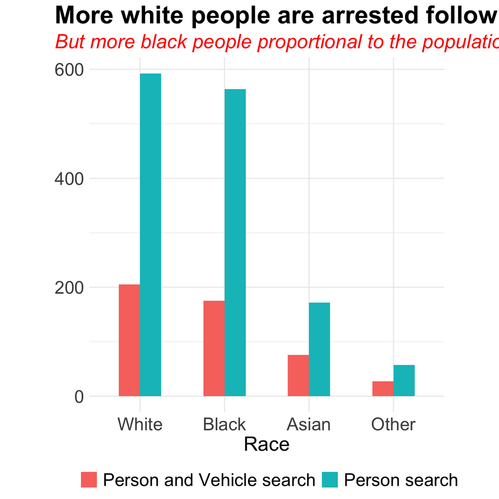

```r
ggplot(data = searches,
       aes(x = fct_reorder(race, count, sum, .desc = TRUE), y = count, fill = type)) +
  geom_col(width = 0.5, position = position_dodge()) +
  labs(title = "More white people are arrested following stop and searches",
       subtitle = "But more black people proportional to the population are arrested following stop and searches",
       x = "Race",
       y = "Number of individuals") +
  theme_minimal() +
  theme(plot.subtitle = element_text(size = 20, face = 'italic', colour = 'red'),
        plot.title = element_text(size = 25, face = 'bold', colour = 'black'),
        aspect.ratio = 1,
        plot.title.position = "plot",
        axis.text = element_text(size = 18),
        axis.title.y = element_blank(),
        axis.title.x = element_text(size = 20),
        legend.text = element_text(size = 18),
        legend.title = element_blank(),
        legend.position = "bottom")
```

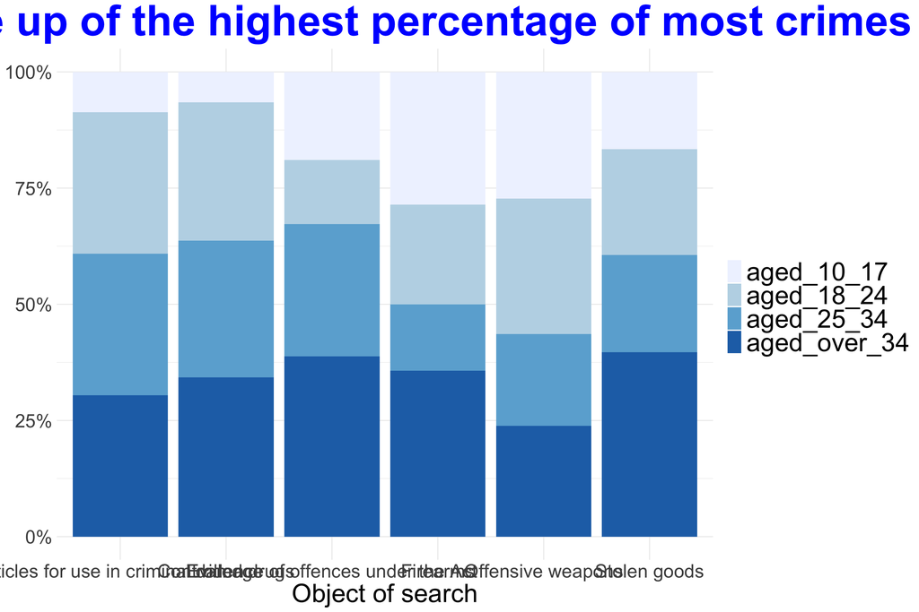

```r
ggplot(data = arrested_wider,
       aes(x = object_of_search, y = percentage, fill = age)) +
  geom_col() +
  scale_fill_brewer(palette = "Blues") +
  theme_minimal() +
  labs(title = "Over 34 y/os make up of the highest percentage of most crimes committed",
       x = "Object of search") +
  scale_y_continuous(labels = scales::percent) +
  theme_minimal() +
  theme(plot.title = element_text(size = 50, face = 'bold', colour = 'blue', hjust = 0.5),
        axis.text = element_text(size = 22),
        axis.title.y = element_blank(),
        axis.title.x = element_text(size = 30),
        legend.text = element_text(size = 30),
        legend.title = element_blank())
```